# Transformar datos

### unitte

Une múltiples columnas en una sola. Es la función inversa de **separatte**

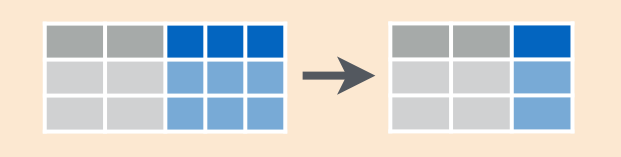

### join

Contiene un conjunto de funciones que se utilizan para unir tablas

fuente: http://rstudio-pubs-static.s3.amazonaws.com/227171_618ebdce0b9d44f3af65700e833593db.html

### Ejemplo

Continuamos con la base de datos **Properati**.

- Pasamos la base a formato “ancho”, donde las columnas sean los años y las observaciones los precios en dólares. En la primera columna debe estar el nombre del barrio.

```r
properati %>% group_by(place_name, year) %>%
               summarise(precio_promedio = mean(price)) %>%
               pivot_wider(names_from = year,values_from = precio_promedio)
```

- Cargamos nuevamente la base “mortalidad infantil” y la transformamos en un formato más largo.

```r
library(openxlsx)

mortalidad_infantil <- read.xlsx("Bases de datos/Mortalidad_infantil.xlsx")

mortalidad_infantil %>% pivot_longer(cols = -country, names_to = "year", values_to = "tasa")
```

- Volvemos a utilizar la base “properati”.

Separamos la columna “lat.lon” en dos columnas: “lat” y “lon”

```r
separate(properati[,c("place_name", "lat.lon")], col = "lat.lon", c("lat", "lon") , sep = ",")
```

```r
unite(properati[, c("price", "currency")], col = "precio_en_USD")
```

- Cargamos una nueva base con los códigos postales de algunos barrios de la Capital Federal, para unirla a la base “properati”.

```r
codigo_postal <- read.csv2("Bases de datos/CP Capital Federal.csv",
                           stringsAsFactors = TRUE)
head(codigo_postal)

# Seleccionamos de la base "properati" las columnas con el nombre de la localidad, el precio en dólares y la cantidad de habitaciones.

properati1 <- properati %>% select(place_name, price, rooms)

# A la base properati le agregamos una columna con los códigos postales de algunos barrios.

properati_cp <- left_join(properati1, codigo_postal, by = "place_name")
head(properati_cp)

# Podemos indicarle que nos devuelva la base pero con las filas que no tengna "NA" en CP
properati_cp %>% filter(complete.cases(CP))
```

## Ejercicios

Trabajar con la base de datos **gapminder** que se encuentra justamente en la librería con el mismo nombre

Para cargar la base se puede hacer de la siguiente manera

```r
gapminder <- gapminder::gapminder # de esta manera no es necesario cargar la librería, simplemente utilizamos una funció, o como este caso, una base de datos de esa librería
```

La fundación Gapminder es una organización sin fines de lucro con sede en Suecia que promueve el desarrollo global mediante el uso de estadísticas que pueden ayudar a reducir mitos comunes e historias sensacionalistas sobre la salud y la economía mundial.

En 2007 Hans Rosling (1948-2017), un médico sueco, dio una de las charlas Ted más famosas. Su presentación mostraba la evolución de tres variables en el tiempo: PIB per cápita, expectativa de vida al nacer y población

- Resolver
1. ¿Cuál es la observación con mayor expectativa al nacer de toda la base? ¿A qué país corresponde y a qué año?
2. ¿Cuánto aumentó la expectativa de vida al nacer por continente en en 2007?
3. Realizar una tabla en formato “wide” en donde las columnas contengan los años, y las observaciones sean los promedios de la población de los paises de América.
4. ¿En qué porcentaje aumentó el PBI per cápita de Argentina en 2007 con respecto a 2002?
5. Unir, con los diferentes métodos de **join**, el dataframe “Gapminder” con el dataframe “mortalidad infantil”, pero solo el año 1952.
1. Utilizar todos los países de ambos dataframes.
2. De ambas bases utilizar solo Argentina.
3. De “gapminder” utilizar todos los países y de “mortalidad infantil” solo Argentina. Visualiza y extraer las dimensiones en cada caso para comparar.